# 01_shadow_speed

## 01_shadow_speed

#### Question

1. At noon, on an [equinox](https://en.wikipedia.org/wiki/Equinox), at the equator, the sun is directly overhead. Over land with minimal elevation change, we can approximate the local ground as flat.

   A rocket is launched at an angle of elevation of 0.825 radians above the horizon at a speed of 3530 meters per second.

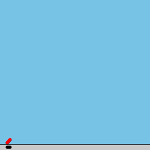

   How fast, in meters per second, is the shadow moving across the flat ground? The tolerance is $\pm 10$ m/s.

#### Question

2. At noon, on an [equinox](https://en.wikipedia.org/wiki/Equinox), at the equator, the sun is directly overhead. Over land with minimal elevation change, we can approximate the local ground as flat.

   A rocket is launched at an angle of elevation of 1.21 radians above the horizon at a speed of 2010 meters per second.

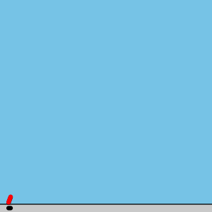

   How fast, in meters per second, is the shadow moving across the flat ground? The tolerance is $\pm 10$ m/s.

#### Question

3. At noon, on an [equinox](https://en.wikipedia.org/wiki/Equinox), at the equator, the sun is directly overhead. Over land with minimal elevation change, we can approximate the local ground as flat.

   A rocket is launched at an angle of elevation of 1.22 radians above the horizon at a speed of 4550 meters per second.

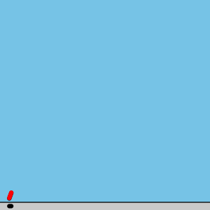

   How fast, in meters per second, is the shadow moving across the flat ground? The tolerance is $\pm 10$ m/s.

#### Question

4. At noon, on an [equinox](https://en.wikipedia.org/wiki/Equinox), at the equator, the sun is directly overhead. Over land with minimal elevation change, we can approximate the local ground as flat.

   A rocket is launched at an angle of elevation of 0.736 radians above the horizon at a speed of 4760 meters per second.

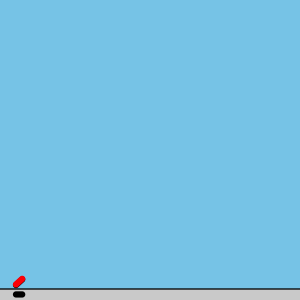

   How fast, in meters per second, is the shadow moving across the flat ground? The tolerance is $\pm 10$ m/s.

#### Question

5. At noon, on an [equinox](https://en.wikipedia.org/wiki/Equinox), at the equator, the sun is directly overhead. Over land with minimal elevation change, we can approximate the local ground as flat.

   A rocket is launched at an angle of elevation of 0.635 radians above the horizon at a speed of 2560 meters per second.

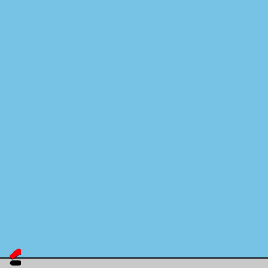

   How fast, in meters per second, is the shadow moving across the flat ground? The tolerance is $\pm 10$ m/s.

#### Question

6. At noon, on an [equinox](https://en.wikipedia.org/wiki/Equinox), at the equator, the sun is directly overhead. Over land with minimal elevation change, we can approximate the local ground as flat.

   A rocket is launched at an angle of elevation of 0.805 radians above the horizon at a speed of 4370 meters per second.

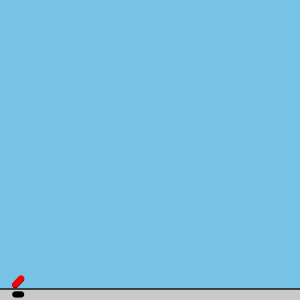

   How fast, in meters per second, is the shadow moving across the flat ground? The tolerance is $\pm 10$ m/s.

#### Question

7. At noon, on an [equinox](https://en.wikipedia.org/wiki/Equinox), at the equator, the sun is directly overhead. Over land with minimal elevation change, we can approximate the local ground as flat.

   A rocket is launched at an angle of elevation of 0.477 radians above the horizon at a speed of 4820 meters per second.

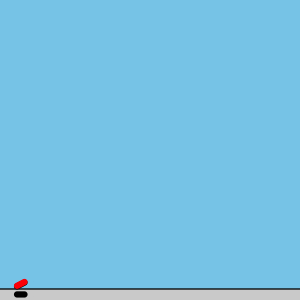

   How fast, in meters per second, is the shadow moving across the flat ground? The tolerance is $\pm 10$ m/s.

#### Question

8. At noon, on an [equinox](https://en.wikipedia.org/wiki/Equinox), at the equator, the sun is directly overhead. Over land with minimal elevation change, we can approximate the local ground as flat.

   A rocket is launched at an angle of elevation of 0.921 radians above the horizon at a speed of 2650 meters per second.

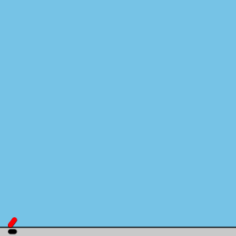

   How fast, in meters per second, is the shadow moving across the flat ground? The tolerance is $\pm 10$ m/s.